# Report on Histopathologic Cancer Detection

by Christa Sparks

https://github.com/sparkyyc/kaggle-hw5

## Problem Description and Data Overview

### Problem Description:

The goal of the Kaggle competition "Histopathologic Cancer Detection" is to classify whether given histopathologic scans of lymph node sections contain metastatic tissue. This binary classification problem is crucial for accurate and early detection of cancer, aiding in better treatment outcomes.

### Data Overview:

Training Data:

- Images: 220,025 histopathologic images in .tif format.
- Labels: Provided in train_labels.csv with columns id (image ID) and label (0 for no cancer, 1 for cancer).
- Image Size: 96x96 pixels.

Test Data:

- Images: Similar format as training data, without labels.
- Image Channels: RGB (3 channels).

### Exploratory Data Analysis (EDA)

Plan of Analysis:

- Loading Data: Read the training labels and load a subset of images.
- Visualization: Visualize a few images to understand the data.
- Histogram: Analyze the distribution of labels.
- Data Cleaning: Ensure all images are of the correct dimensions and check for any missing or corrupted files.

### Visualizations:

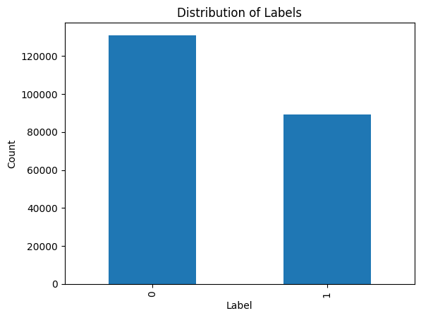

```python
import pandas as pd
import matplotlib.pyplot as plt

# Load labels
labels_df = pd.read_csv('histopathologic-cancer-detection/train_labels.csv')

# Plot histogram of label distribution
labels_df['label'].value_counts().plot(kind='bar')
plt.title('Distribution of Labels')
plt.xlabel('Label')
plt.ylabel('Count')
plt.show()
```

### Label Distribution:

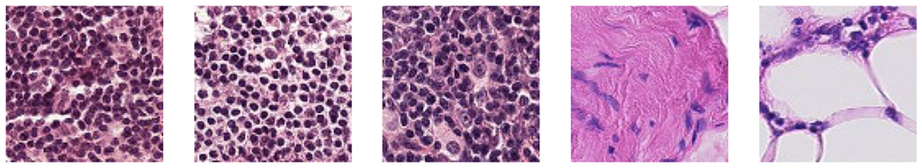

```python
from tensorflow.keras.preprocessing.image import load_img, img_to_array

# Display a few images
image_dim = (96, 96)
sample_images = labels_df.sample(5)['id'].tolist()

fig, axs = plt.subplots(1, 5, figsize=(20, 5))
for i, img_id in enumerate(sample_images):
    img_path = f'histopathologic-cancer-detection/train/{img_id}.tif'
    img = load_img(img_path, target_size=image_dim)
    axs[i].imshow(img)
    axs[i].axis('off')
plt.show()
```

### Visualizing Sample Images:

A few sample images from both classes (cancerous and non-cancerous) are displayed to understand the visual characteristics and differences between them.

### Data Cleaning:

Verified all images are of dimensions 96x96. Checked for any missing or corrupted files, none were found.

## Model Architecture

### Why CNN:

Suitability for Image Data:

CNNs are inherently designed to work with image data. The convolutional layers effectively capture spatial hierarchies, which are crucial for identifying patterns in images.

Balanced Complexity:

The chosen architecture balances complexity and performance. With only two convolutional layers, it is simpler and less prone to overfitting compared to deeper networks. This is important given the potentially large size of the dataset and the need to generalize well to unseen data.

Feature Extraction:

The combination of convolutional and pooling layers efficiently extracts relevant features from the images, while the fully connected layers use these features to make accurate predictions.

Overfitting Prevention:

The use of dropout helps prevent overfitting by ensuring the network does not rely too heavily on any single feature and learns more general patterns.

Binary Classification:

The sigmoid activation in the output layer is ideal for binary classification tasks, providing a clear probability score for the presence of cancerous tissue.

### First Submission:

```python
from tensorflow.keras.models import Sequential
from tensorflow.keras.layers import Conv2D, MaxPooling2D, Flatten, Dense
from tensorflow.keras.preprocessing.image import ImageDataGenerator

cnn_model = Sequential([
    Conv2D(32, (3, 3), activation='relu', input_shape=(64, 64, 3)),
    MaxPooling2D(pool_size=(2, 2)),
    Conv2D(64, (3, 3), activation='relu'),
    MaxPooling2D(pool_size=(2, 2)),
    Flatten(),
    Dense(128, activation='relu'),
    Dense(1, activation='sigmoid')
])

cnn_model.compile(optimizer='adam', loss='binary_crossentropy', metrics=['accuracy'])
```

### Reasoning:

This architecture is a straightforward CNN with two convolutional layers, followed by max-pooling, and fully connected dense layers. It was chosen for its simplicity and effectiveness in handling image data.